# Clustering hiérarchique et KMeans clustering

```python
# Importation de librairies standards:
import numpy as np
import pandas as pd
import matplotlib.pyplot as plt
from sklearn.model_selection import train_test_split
# Importation de la librairie seaborn:
import seaborn as sns
sns.set_theme(style="whitegrid")
%matplotlib inline

# un nouvel import utile pour la 3D:
from matplotlib import cm

# Pour mesurer le temps
import time

# Importation de votre librairie iads:
# La ligne suivante permet de préciser le chemin d'accès à la librairie iads
# import sys
# sys.path.append('../')   # iads doit être dans le répertoire père du répertoire courant !

# Importation de la librairie iads
import iads as iads

# importation de Classifiers
from iads import Classifiers as classif

# importation de utils
from iads import utils as ut

# importation de evaluation
from iads import evaluation as ev

# importation de Clustering
from iads import Clustering as clust

# commande TRES utile pour recharger automatiquement le code que vous modifiez dans les modules
%load_ext autoreload
%autoreload 2
```

```python
import warnings

# Suppress all warnings
warnings.filterwarnings("ignore")

# Suppress a specific warning type
warnings.filterwarnings("ignore", category=DeprecationWarning)
```

```python
import os
from os import listdir
parent_dir = os.path.abspath(os.path.join(os.getcwd(), '..'))  # Get the parent directory
os.chdir(parent_dir)  # Change the working directory to the parent directory
os.sys.path.append(parent_dir)  # Append the parent directory to the system path
listdir()
```

```
['test copy.ipynb',
 'Q3.ipynb',
 'side.ipynb',
 'main.ipynb',
 'Test',
 'fatigue_analysis.ipynb',
 'Sujet de test.pdf',
 'README.md',
 'classifier',
 'main copie.html',
 'classifier.ipynb',
 '.gitattributes',
 '.git',
 '.vscode',
 'test.ipynb']
```

### Chargement des données

```python
# Load the data
df = pd.read_json("Test/ergometer_500m.json")
```

```python
# Calcul de la vitesse en km/h (distance en km / temps en heures)
df['split_time_hours'] = df['split_time'] / 3600  # Conversion du temps en heures
df['speed_kmh'] = (0.5 / df['split_time_hours'])  # La distance est de 0.5 km (500m)
df['speed_category'] = pd.cut(df['speed_kmh'], bins=[0, 13.5, 15, 20], labels=[0, 1, 2])

X = df[['split_calories','split_drag_factor','split_stroke_rate','split_stroke_count','split_time']]
y = df['speed_category']

X_noms = X.columns
```

# Expérimentations

```python
# Définition de variables
X_noms = X.columns

dim = len(X)
nb_labels = len(np.unique(y))
```

## Prétraitement de données

### Normalisation de données

```python
import random

index = random.sample(range(len(X)),100)
X_norm = clust.normalisation(X.iloc[index])
y_target = y.iloc[index]

print("Les valeurs uniques de y_target :",np.unique(y_target))
```

```
Les valeurs uniques de y_target : [0 1 2]
```

### Réduction de 5D à 2D et 3D

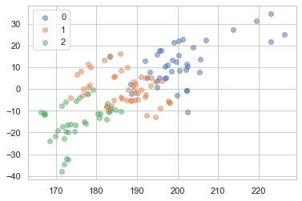

```python
# A réaliser :

# 1) calcul des vecteurs propres
lam_train, V_train = np.linalg.eig(X.T @ X)
# lam_test, V_test = np.linalg.eig(XTu.T @ XTu)

# Trouver les indices des deux plus grandes valeurs propres
largest_indices = np.argsort(lam_train)[::-1][:2]



# Extraire les deux plus grandes valeurs propres et leurs vecteurs propres correspondants
largest_eigenvalues = lam_train[largest_indices]


max_train = V_train[:, largest_indices]
# max_test = V_test[:, np.argmax(lam_test)]


# 2) affichage (print)
#print("1er valeur rendue:\n", lam_train)
#print("2e valeur rendue :\n", V_train)

# 3) tri et sélection des 2 vecteurs associés aux 2 plus grandes valeurs propres
#print("Vecteur train :\n", max_train)

# 4) affichage (plot) avec un code couleur pour les classes
for i in np.unique(y) :
  one_train = X[y==i]
  #print(one_train)

  projected_data_train = np.dot(one_train, max_train)

  plt.scatter(projected_data_train[:,0], projected_data_train[:,1],alpha=.5)


# ####################################
plt.legend(np.arange(10))

#plt.savefig("out/proj_usps_all.png",bbox_inches='tight', transparent=True,pad_inches=0)
```

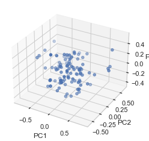

```python
from mpl_toolkits.mplot3d import Axes3D
from sklearn.decomposition import PCA
import random

# Perform PCA to reduce the dimensionality to 3D
pca = PCA(n_components=3)
X_projected_3D = pca.fit_transform(X_norm)

# Plot the reduced data
fig = plt.figure()
ax = fig.add_subplot(111, projection='3d')
ax.scatter(X_projected_3D[:, 0], X_projected_3D[:, 1], X_projected_3D[:, 2])
ax.set_xlabel('PC1')
ax.set_ylabel('PC2')
ax.set_zlabel('PC3')
plt.show()
```

## Clustering hiérachique

### Algorithme de classification hiérarchique

#### Linkage = centroid

[output not shown]

[output cut: 540 more lines]

```
fusionne: les clés de [ 74 , 174 ] sont supprimées car leurs clusters ont été fusionnés.
CHA_centroid: une fusion réalisée de   74  avec  174  de distance   0.5555615409423231
CHA_centroid: le nouveau cluster contient   4   exemples
fusionne: distance mininimale trouvée entre [ 195 , 196 ] =  0.7853071358993213
fusionne: les 2 clusters dont les clés sont [ 195 , 196 ] sont fusionnés
fusionne: on crée la  nouvelle clé  3  dans le dictionnaire.
fusionne: les clés de [ 195 , 196 ] sont supprimées car leurs clusters ont été fusionnés.
CHA_centroid: une fusion réalisée de   195  avec  196  de distance   0.7853071358993213
CHA_centroid: le nouveau cluster contient   96   exemples
fusionne: distance mininimale trouvée entre [ 185 , 197 ] =  0.8951600362304809
fusionne: les 2 clusters dont les clés sont [ 185 , 197 ] sont fusionnés
fusionne: on crée la  nouvelle clé  2  dans le dictionnaire.
fusionne: les clés de [ 185 , 197 ] sont supprimées car leurs clusters ont été fusionnés.
CHA_centroid: une fusion réalisée de   185  avec  197  de distance   0.8951600362304809
CHA_centroid: le nouveau cluster contient   100   exemples
```

```
[[26, 76, 0.019416251656023214, 2],
 [72, 86, 0.027159317610767942, 2],
 [59, 62, 0.03992472205833346, 2],
 [43, 79, 0.040226800377956895, 2],
 [3, 64, 0.053283745087980686, 2],
 [47, 95, 0.05639061192737546, 2],
 [36, 41, 0.059297391782361916, 2],
 [27, 28, 0.0661653109426702, 2],
 [12, 96, 0.06649234116991452, 2],
 [16, 61, 0.06830416724120573, 2],
 [39, 100, 0.07113629096907885, 3],
 [9, 48, 0.07201209102782564, 2],
 [0, 94, 0.07287829073141797, 2],
 [52, 91, 0.07324580049755729, 2],
 [21, 25, 0.07380196762001039, 2],
```

[output cut: 84 more lines]

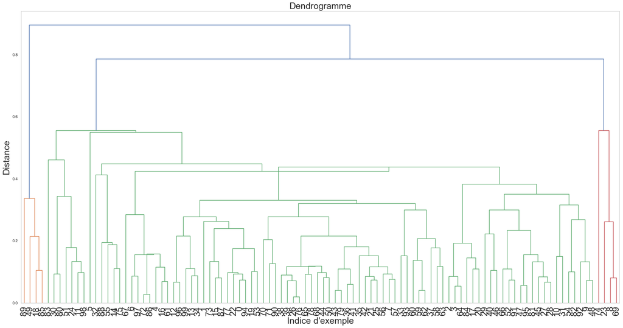

```python
clust.CHA(pd.DataFrame(X_norm),linkage='centroid',dendrogramme=True,verbose=True)
```

#### Linkage = complete

[output not shown]

[output cut: 708 more lines]

```
fusionne: les clés de [ 234 , 245 ] sont supprimées car leurs clusters ont été fusionnés.
CHA_centroid: une fusion réalisée de   234  avec  245  de distance   1.2268776760910687
CHA_centroid: le nouveau cluster contient   33   exemples
fusionne: distance mininimale trouvée entre [ 250 , 252 ] =  1.464655217257592
fusionne: les 2 clusters dont les clés sont [ 250 , 252 ] sont fusionnés
fusionne: on crée la  nouvelle clé  3  dans le dictionnaire.
fusionne: les clés de [ 250 , 252 ] sont supprimées car leurs clusters ont été fusionnés.
CHA_centroid: une fusion réalisée de   250  avec  252  de distance   1.464655217257592
CHA_centroid: le nouveau cluster contient   101   exemples
fusionne: distance mininimale trouvée entre [ 251 , 253 ] =  1.670308770965733
fusionne: les 2 clusters dont les clés sont [ 251 , 253 ] sont fusionnés
fusionne: on crée la  nouvelle clé  2  dans le dictionnaire.
fusionne: les clés de [ 251 , 253 ] sont supprimées car leurs clusters ont été fusionnés.
CHA_centroid: une fusion réalisée de   251  avec  253  de distance   1.670308770965733
CHA_centroid: le nouveau cluster contient   128   exemples
```

```
[[5, 6, 0.019416251656023214, 2],
 [109, 110, 0.019962361029166684, 2],
 [111, 115, 0.027159317610767942, 2],
 [26, 31, 0.02784353308558243, 2],
 [11, 65, 0.03711338249706607, 2],
 [41, 42, 0.03992472205833346, 2],
 [33, 35, 0.040226800377956895, 2],
 [23, 32, 0.0523335522042979, 2],
 [100, 101, 0.053283745087980686, 2],
 [1, 49, 0.05602395148824334, 2],
 [3, 51, 0.05639061192737546, 2],
 [29, 131, 0.059297391782361916, 3],
 [2, 8, 0.0661653109426702, 2],
 [69, 70, 0.06649234116991452, 2],
 [113, 114, 0.06830416724120573, 2],
```

[output cut: 112 more lines]

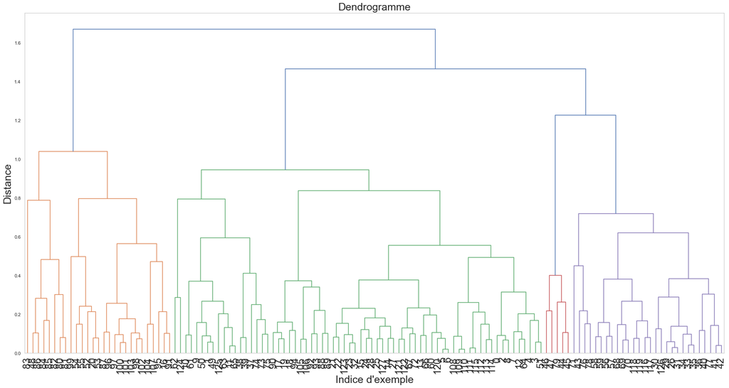

```python
clust.CHA(pd.DataFrame(X_norm),linkage='complete',dendrogramme=True,verbose=True)
```

#### Linkage = simple

[output not shown]

[output cut: 708 more lines]

```
fusionne: les clés de [ 62 , 251 ] sont supprimées car leurs clusters ont été fusionnés.
CHA_centroid: une fusion réalisée de   62  avec  251  de distance   0.2861334568514493
CHA_centroid: le nouveau cluster contient   122   exemples
fusionne: distance mininimale trouvée entre [ 249 , 252 ] =  0.30536960268587066
fusionne: les 2 clusters dont les clés sont [ 249 , 252 ] sont fusionnés
fusionne: on crée la  nouvelle clé  3  dans le dictionnaire.
fusionne: les clés de [ 249 , 252 ] sont supprimées car leurs clusters ont été fusionnés.
CHA_centroid: une fusion réalisée de   249  avec  252  de distance   0.30536960268587066
CHA_centroid: le nouveau cluster contient   127   exemples
fusionne: distance mininimale trouvée entre [ 83 , 253 ] =  0.3812882412123512
fusionne: les 2 clusters dont les clés sont [ 83 , 253 ] sont fusionnés
fusionne: on crée la  nouvelle clé  2  dans le dictionnaire.
fusionne: les clés de [ 83 , 253 ] sont supprimées car leurs clusters ont été fusionnés.
CHA_centroid: une fusion réalisée de   83  avec  253  de distance   0.3812882412123512
CHA_centroid: le nouveau cluster contient   128   exemples
```

```
[[5, 6, 0.019416251656023214, 2],
 [109, 110, 0.019962361029166684, 2],
 [111, 115, 0.027159317610767942, 2],
 [26, 31, 0.02784353308558243, 2],
 [11, 65, 0.03711338249706607, 2],
 [41, 42, 0.03992472205833346, 2],
 [33, 35, 0.040226800377956895, 2],
 [23, 32, 0.0523335522042979, 2],
 [100, 101, 0.053283745087980686, 2],
 [1, 49, 0.05602395148824334, 2],
 [3, 51, 0.05639061192737546, 2],
 [29, 131, 0.05757070253641957, 3],
 [2, 137, 0.06539168513815116, 3],
 [8, 140, 0.0661653109426702, 4],
 [50, 141, 0.06626285517402554, 5],
```

[output cut: 112 more lines]

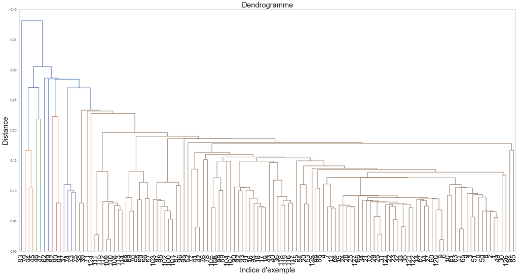

```python
clust.CHA(pd.DataFrame(X_norm),linkage='simple',dendrogramme=True,verbose=True)
```

#### Linkage = average

[output not shown]

[output cut: 708 more lines]

```
fusionne: les clés de [ 231 , 250 ] sont supprimées car leurs clusters ont été fusionnés.
CHA_centroid: une fusion réalisée de   231  avec  250  de distance   0.692635387154252
CHA_centroid: le nouveau cluster contient   121   exemples
fusionne: distance mininimale trouvée entre [ 251 , 252 ] =  0.9035404591906073
fusionne: les 2 clusters dont les clés sont [ 251 , 252 ] sont fusionnés
fusionne: on crée la  nouvelle clé  3  dans le dictionnaire.
fusionne: les clés de [ 251 , 252 ] sont supprimées car leurs clusters ont été fusionnés.
CHA_centroid: une fusion réalisée de   251  avec  252  de distance   0.9035404591906073
CHA_centroid: le nouveau cluster contient   123   exemples
fusionne: distance mininimale trouvée entre [ 235 , 253 ] =  0.9609806414741466
fusionne: les 2 clusters dont les clés sont [ 235 , 253 ] sont fusionnés
fusionne: on crée la  nouvelle clé  2  dans le dictionnaire.
fusionne: les clés de [ 235 , 253 ] sont supprimées car leurs clusters ont été fusionnés.
CHA_centroid: une fusion réalisée de   235  avec  253  de distance   0.9609806414741466
CHA_centroid: le nouveau cluster contient   128   exemples
```

```
[[5, 6, 0.019416251656023214, 2],
 [109, 110, 0.019962361029166684, 2],
 [111, 115, 0.027159317610767942, 2],
 [26, 31, 0.02784353308558243, 2],
 [11, 65, 0.03711338249706607, 2],
 [41, 42, 0.03992472205833346, 2],
 [33, 35, 0.040226800377956895, 2],
 [23, 32, 0.0523335522042979, 2],
 [100, 101, 0.053283745087980686, 2],
 [1, 49, 0.05602395148824334, 2],
 [3, 51, 0.05639061192737546, 2],
 [29, 131, 0.05843404715939074, 3],
 [2, 8, 0.0661653109426702, 2],
 [69, 70, 0.06649234116991452, 2],
 [113, 114, 0.06830416724120573, 2],
```

[output cut: 112 more lines]

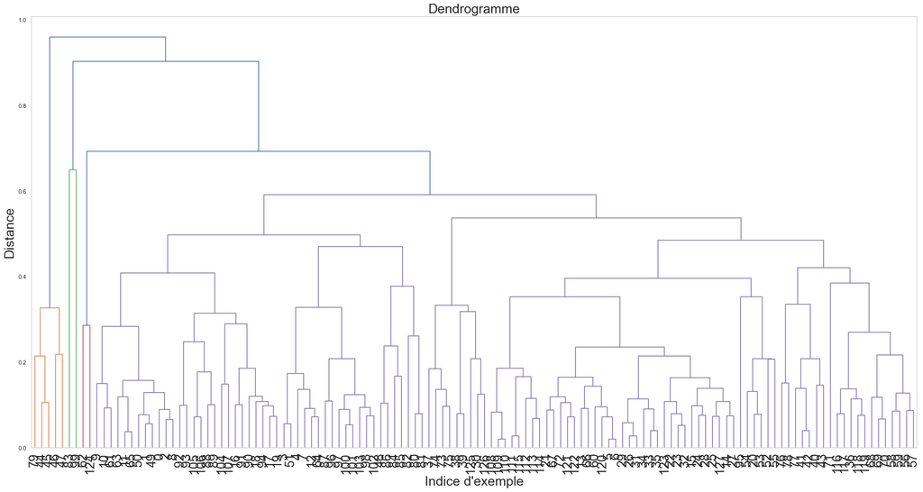

```python
clust.CHA(pd.DataFrame(X_norm),linkage='average',dendrogramme=True,verbose=True)
```

## Algorithme des K-moyennes

### Normalisation de données

Pour l'algorithme des K-moyennes, nous allons utiliser toutes les données de la base pendataset.

```python
X_norm = clust.normalisation(X)
print(f"inertie de la base de données : {clust.inertie_cluster(X_norm):1.4f}")
```

```
inertie de la base de données : 23.5774
```

On a constaté que le modèle a une inertie de 23.5774. C'est un bon ajustement du modèle aux données.

### The Elbow method

Le méthode du coude *(ou The Elbow method)* est utilisée pour déterminer le nombre optimal de clusters dans le clustering K-means. La méthode du coude trace la valeur de la fonction de coût produite par différentes valeurs de K.

Si K augmente, la distorsion moyenne diminuera. Ensuite, chaque cluster aura moins d'instances constitutives, et les instances seront plus proches de leurs centroïdes respectifs. Cependant, les améliorations de la distorsion moyenne diminueront à mesure que K augmente. La valeur de K à laquelle l'amélioration de la distorsion diminue le plus est appelée le coude, auquel nous devrions arrêter de diviser les données en clusters supplémentaires.

Dans ce projet, comme la version de la fonction qui calcule l'inertie n'est pas adaptée pour chaque valeur de K dans l'algorithme de K-moyennes, on va utiliser la classe `KMeans` de la librairie `sklearn.cluster`.

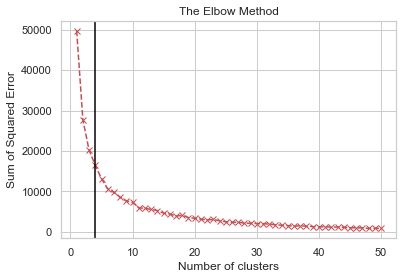

```python
from sklearn.cluster import KMeans

cs = []
for i in range(1, 51):
    kmeans = KMeans(n_clusters = i)
    kmeans.fit(X)
    cs.append(kmeans.inertia_)
plt.plot(range(1, 51), cs, linestyle="--",marker='x',color='r')
plt.axvline(x=4, color='black', linestyle='-')
plt.title('The Elbow Method')
plt.xlabel('Number of clusters')
plt.ylabel('Sum of Squared Error')
plt.show()
```

On a appliqué la méthode du coude et on a constaté que $k=4$ (où $k$ est le nombre de clusters) peut être considéré comme un bon nombre de clusters pour regrouper ces données.

```python
np.random.seed(42)   # supprimer cette ligne une fois la mise au point terminée

# Par exemple (mais vous ne devriez pas pouvoir retrouver exactement les mêmes !)
Centroides_test = clust.init_kmeans(10,X)

pp = []
# Exemple (vérifier le résultat avec l'affichage graphique réalisé précédemment):
for i in range(0,len(X)):
    pproche = clust.plus_proche(X.iloc[i],Centroides_test)
    print("L'exemple ",i," est le plus proche du centroide ",pproche)
    pp.append(pproche)
```

```
L'exemple  0  est le plus proche du centroide  2
L'exemple  1  est le plus proche du centroide  2
L'exemple  2  est le plus proche du centroide  2
L'exemple  3  est le plus proche du centroide  4
L'exemple  4  est le plus proche du centroide  4
L'exemple  5  est le plus proche du centroide  2
L'exemple  6  est le plus proche du centroide  2
L'exemple  7  est le plus proche du centroide  2
L'exemple  8  est le plus proche du centroide  2
L'exemple  9  est le plus proche du centroide  2
L'exemple  10  est le plus proche du centroide  2
L'exemple  11  est le plus proche du centroide  2
L'exemple  12  est le plus proche du centroide  2
L'exemple  13  est le plus proche du centroide  2
L'exemple  14  est le plus proche du centroide  0
L'exemple  15  est le plus proche du centroide  0
L'exemple  16  est le plus proche du centroide  2
L'exemple  17  est le plus proche du centroide  2
L'exemple  18  est le plus proche du centroide  2
L'exemple  19  est le plus proche du centroide  2
L'exemple  20  est le plus proche du centroide  0
L'exemple  21  est le plus proche du centroide  0
L'exemple  22  est le plus proche du centroide  3
L'exemple  23  est le plus proche du centroide  3
L'exemple  24  est le plus proche du centroide  0
L'exemple  25  est le plus proche du centroide  9
L'exemple  26  est le plus proche du centroide  9
L'exemple  27  est le plus proche du centroide  9
L'exemple  28  est le plus proche du centroide  9
L'exemple  29  est le plus proche du centroide  9
L'exemple  30  est le plus proche du centroide  3
L'exemple  31  est le plus proche du centroide  3
L'exemple  32  est le plus proche du centroide  9
L'exemple  33  est le plus proche du centroide  3
L'exemple  34  est le plus proche du centroide  3
L'exemple  35  est le plus proche du centroide  3
L'exemple  36  est le plus proche du centroide  1
L'exemple  37  est le plus proche du centroide  3
L'exemple  38  est le plus proche du centroide  1
L'exemple  39  est le plus proche du centroide  1
```

[output cut: 73 more lines]

```
L'exemple  113  est le plus proche du centroide  0
L'exemple  114  est le plus proche du centroide  0
L'exemple  115  est le plus proche du centroide  0
L'exemple  116  est le plus proche du centroide  6
L'exemple  117  est le plus proche du centroide  6
L'exemple  118  est le plus proche du centroide  6
L'exemple  119  est le plus proche du centroide  6
L'exemple  120  est le plus proche du centroide  2
L'exemple  121  est le plus proche du centroide  3
L'exemple  122  est le plus proche du centroide  9
L'exemple  123  est le plus proche du centroide  0
L'exemple  124  est le plus proche du centroide  0
L'exemple  125  est le plus proche du centroide  2
L'exemple  126  est le plus proche du centroide  9
L'exemple  127  est le plus proche du centroide  9
```

### K-Means model with different clusters

#### Pour K = 3 :

```python
np.random.seed(42)   # supprimer cette ligne une fois la mise au point terminée

les_centres, l_affectation = clust.kmoyennes(3, X, 0.05, 100)

print("Affichage des centres: \n",les_centres)
print("Affichage des affectations: \n",l_affectation)

s = 0
for (k,v) in l_affectation.items() :
  target = y.iloc[v]
  s += sum(np.array(target) == k)

print("Result: %d out of %d samples were correctly labeled." % (s, y.size))
print('Accuracy score: {0:0.2f}'. format(int(s)/float(y.size)))
```

```
Iteration 1 Inertie : 21920.087211876173 Différence : 2606.832733533254
Iteration 2 Inertie : 21015.880134553132 Différence : 904.2070773230407
Iteration 3 Inertie : 20667.68324665091 Différence : 348.1968879022206
Iteration 4 Inertie : 20404.716377777782 Différence : 262.966868873129
Iteration 5 Inertie : 20336.186369932646 Différence : 68.53000784513642
Iteration 6 Inertie : 20319.800483870968 Différence : 16.38588606167832
Iteration 7 Inertie : 20319.800483870968 Différence : 0.0
Affichage des centres:
 [[ 30.29032258 115.4516129   29.30645161  63.29032258 129.8483871 ]
 [ 27.04166667 113.95833333  28.95833333  72.45833333 149.775     ]
 [ 36.04761905 116.19047619  29.16666667  54.26190476 111.76666667]]
Affichage des affectations:
 {0: [5, 6, 9, 10, 11, 13, 14, 15, 20, 21, 22, 23, 24, 25, 27, 28, 32, 33, 36, 53, 54, 55, 56, 57, 58, 59, 60, 61, 62, 63, 65, 66, 67, 68, 69, 70, 71, 72, 92, 93, 94, 95, 108, 109, 110, 111, 112, 113, 114, 115, 116, 117, 118, 119, 120, 121, 122, 123, 124, 125, 126, 127], 1: [26, 29, 30, 31, 34, 35, …
Result: 51 out of 128 samples were correctly labeled.
Accuracy score: 0.40
```

##### Visualisation

```
Iteration 1 Inertie : 6.238727614163658 Différence : 2.090007350425422
Iteration 2 Inertie : 6.225879061226662 Différence : 0.012848552936995716
Affichage des centres:
 [[ 1.04111376  0.15717623]
 [ 0.74093503  0.24744128]
 [ 0.98627108 -0.26575174]]
Affichage des affectations:
 {0: [1, 4, 6, 14, 16, 17, 20, 26, 32, 38, 39, 44, 52, 55, 56, 61, 66, 67, 68, 72, 74, 75, 76, 78, 83, 84, 86, 88, 91, 97], 1: [0, 2, 3, 8, 9, 10, 19, 22, 23, 27, 28, 29, 30, 31, 34, 40, 45, 46, 47, 48, 53, 54, 64, 69, 77, 80, 81, 82, 92, 94, 95], 2: [5, 7, 11, 12, 13, 15, 18, 21, 24, 25, 33, 35, 36…
```

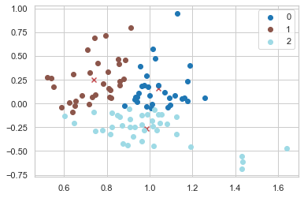

```python
np.random.seed(42)   # supprimer cette ligne une fois la mise au point terminée

les_centres, l_affectation = clust.kmoyennes(3, pd.DataFrame(X_projected_2D), 0.05, 100)
print("Affichage des centres: \n",les_centres)
print("Affichage des affectations: \n",l_affectation)

clust.affiche_resultat(pd.DataFrame(X_projected_2D),les_centres,l_affectation)
```

#### Pour K = 4 :

```python
np.random.seed(42)   # supprimer cette ligne une fois la mise au point terminée

les_centres, l_affectation = clust.kmoyennes(4, X, 0.05, 100)

print("Affichage des centres: \n",les_centres)
print("Affichage des affectations: \n",l_affectation)

s = 0
for (k,v) in l_affectation.items() :
  target = y.iloc[v]
  s += sum(np.array(target) == k)

print("Result: %d out of %d samples were correctly labeled." % (s, y.size))
print('Accuracy score: {0:0.2f}'. format(int(s)/float(y.size)))
```

```
Iteration 1 Inertie : 20443.326856803324 Différence : 3218.9899804511006
Iteration 2 Inertie : 17949.72945098039 Différence : 2493.597405822933
Iteration 3 Inertie : 17554.810519065333 Différence : 394.9189319150573
Iteration 4 Inertie : 17150.093758169933 Différence : 404.7167608954005
Iteration 5 Inertie : 17070.40870760234 Différence : 79.68505056759386
Iteration 6 Inertie : 17048.864072649572 Différence : 21.5446349527665
Iteration 7 Inertie : 17048.864072649572 Différence : 0.0
Affichage des centres:
 [[ 30.17777778 119.82222222  29.31111111  63.44444444 130.26666667]
 [ 30.95       104.65        29.15        62.05       127.445     ]
 [ 36.28205128 116.74358974  29.23076923  54.02564103 111.12564103]
 [ 27.04166667 113.95833333  28.95833333  72.45833333 149.775     ]]
Affichage des affectations:
 {0: [5, 6, 9, 10, 11, 13, 14, 15, 20, 21, 22, 23, 24, 25, 27, 28, 32, 33, 53, 54, 55, 60, 61, 62, 63, 65, 66, 67, 72, 108, 109, 110, 111, 112, 113, 114, 115, 120, 121, 122, 123, 124, 125, 126, 127], 1: [16, 17, 18, 36, 56, 57, 58, 59, 68, 69, 70, 71, 92, 93, 94, 95, 116, 117, 118, 119], 2: [0, 1, 2…
Result: 64 out of 128 samples were correctly labeled.
Accuracy score: 0.50
```

##### Visualisation 2D

```
Iteration 1 Inertie : 4.369341270150835 Différence : 1.4185262571305763
Iteration 2 Inertie : 4.041008984112877 Différence : 0.3283322860379583
Iteration 3 Inertie : 4.003138995073474 Différence : 0.037869989039402974
Affichage des centres:
 [[ 1.02787956  0.02410264]
 [ 0.70869178  0.06259879]
 [ 1.03225918 -0.33993614]
 [ 0.89522304  0.50139614]]
Affichage des affectations:
 {0: [1, 4, 6, 7, 14, 16, 25, 26, 35, 38, 39, 42, 44, 50, 52, 55, 56, 57, 61, 65, 67, 68, 71, 72, 75, 76, 78, 83, 86, 88, 91, 97], 1: [0, 9, 13, 15, 19, 22, 27, 28, 30, 31, 34, 45, 48, 53, 54, 70, 77, 80, 81, 82, 87, 92, 94, 95, 99], 2: [5, 11, 12, 18, 21, 24, 33, 36, 37, 41, 43, 49, 51, 58, 59, 60,…
```

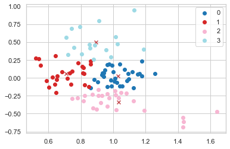

```python
np.random.seed(42)   # supprimer cette ligne une fois la mise au point terminée

les_centres, l_affectation = clust.kmoyennes(4, pd.DataFrame(X_projected_2D), 0.05, 100)

print("Affichage des centres: \n",les_centres)
print("Affichage des affectations: \n",l_affectation)

clust.affiche_resultat(pd.DataFrame(X_projected_2D),les_centres,l_affectation)
```

#### Pour K = 5 :

```python
np.random.seed(42)   # supprimer cette ligne une fois la mise au point terminée

les_centres, l_affectation = clust.kmoyennes(5, X, 0.05, 100)

print("Affichage des centres: \n",les_centres)
print("Affichage des affectations: \n",l_affectation)

s = 0
for (k,v) in l_affectation.items() :
  target = y.iloc[v]
  s += sum(np.array(target) == k)

print("Result: %d out of %d samples were correctly labeled." % (s, y.size))
print('Accuracy score: {0:0.2f}'. format(int(s)/float(y.size)))
```

```
Iteration 1 Inertie : 16307.92524598563 Différence : 1531.4921349667475
Iteration 2 Inertie : 15070.897824363137 Différence : 1237.0274216224934
Iteration 3 Inertie : 14629.138178505704 Différence : 441.7596458574335
Iteration 4 Inertie : 14532.26351622591 Différence : 96.87466227979348
Iteration 5 Inertie : 14532.26351622591 Différence : 0.0
Affichage des centres:
 [[ 30.3        120.2         30.          64.825      130.0625    ]
 [ 29.42105263 105.36842105  28.94736842  64.73684211 134.44736842]
 [ 32.55172414 114.4137931   27.51724138  55.34482759 120.91034483]
 [ 26.89473684 114.89473684  29.57894737  74.63157895 151.09473684]
 [ 38.80952381 117.23809524  29.85714286  52.19047619 105.00952381]]
Affichage des affectations:
 {0: [5, 6, 13, 14, 15, 20, 21, 22, 23, 24, 27, 28, 32, 33, 52, 53, 54, 55, 60, 62, 63, 66, 67, 72, 108, 109, 110, 111, 112, 113, 114, 115, 120, 121, 122, 123, 124, 125, 126, 127], 1: [25, 29, 30, 36, 38, 39, 40, 56, 57, 58, 59, 68, 69, 70, 71, 116, 117, 118, 119], 2: [0, 1, 2, 3, 4, 7, 8, 9, 10, 11…
Result: 37 out of 128 samples were correctly labeled.
Accuracy score: 0.29
```

##### Visualisation

```
Iteration 1 Inertie : 3.771631358736891 Différence : 1.0622345377482434
Iteration 2 Inertie : 3.405822662564231 Différence : 0.3658086961726599
Iteration 3 Inertie : 3.2399424026198953 Différence : 0.16588025994433586
Iteration 4 Inertie : 3.0454873477795763 Différence : 0.194455054840319
Iteration 5 Inertie : 2.8165774457304256 Différence : 0.22890990204915074
Iteration 6 Inertie : 2.6794411256370383 Différence : 0.13713632009338728
Iteration 7 Inertie : 2.6744677012529423 Différence : 0.004973424384095981
Affichage des centres:
 [[ 1.04178327  0.08398719]
 [ 0.70801065  0.10765005]
 [ 0.93496148 -0.23523223]
 [ 0.88035041  0.55750179]
 [ 1.42364115 -0.55698615]]
Affichage des affectations:
 {0: [1, 4, 6, 14, 16, 26, 32, 38, 39, 44, 52, 55, 56, 57, 61, 66, 67, 68, 72, 75, 76, 78, 83, 86, 88, 91, 97], 1: [0, 9, 10, 13, 19, 22, 27, 28, 30, 31, 34, 45, 47, 48, 53, 54, 70, 77, 80, 81, 82, 92, 94, 95], 2: [5, 7, 11, 12, 15, 21, 24, 25, 33, 35, 36, 37, 41, 42, 43, 50, 51, 58, 59, 60, 62, 63,…
```

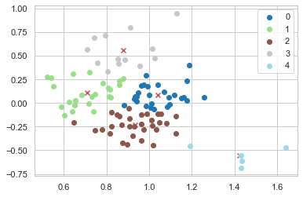

```python
np.random.seed(42)   # supprimer cette ligne une fois la mise au point terminée

les_centres, l_affectation = clust.kmoyennes(5, pd.DataFrame(X_projected_2D), 0.05, 100)

print("Affichage des centres: \n",les_centres)
print("Affichage des affectations: \n",l_affectation)

clust.affiche_resultat(pd.DataFrame(X_projected_2D),les_centres,l_affectation)
```

#### Pour K = 6 :

```python
np.random.seed(42)   # supprimer cette ligne une fois la mise au point terminée

les_centres, l_affectation = clust.kmoyennes(6, X, 0.05, 100)

print("Affichage des centres: \n",les_centres)
print("Affichage des affectations: \n",l_affectation)

s = 0
for (k,v) in l_affectation.items() :
  target = y.iloc[v]
  s += sum(np.array(target) == k)

print("Result: %d out of %d samples were correctly labeled." % (s, y.size))
print('Accuracy score: {0:0.2f}'. format(int(s)/float(y.size)))
```

```
Iteration 1 Inertie : 14398.725155480293 Différence : 1998.1630263378865
Iteration 2 Inertie : 12658.396839769426 Différence : 1740.3283157108672
Iteration 3 Inertie : 11484.422698412698 Différence : 1173.974141356728
Iteration 4 Inertie : 10680.521411149826 Différence : 803.9012872628718
Iteration 5 Inertie : 10653.791892857142 Différence : 26.72951829268459
Iteration 6 Inertie : 10653.791892857142 Différence : 0.0
Affichage des centres:
 [[ 30.325      120.1         30.025       64.825      129.9475    ]
 [ 27.42105263 113.52631579  27.31578947  66.52631579 146.39473684]
 [ 32.53571429 114.64285714  27.32142857  55.         120.98571429]
 [ 26.         115.83333333  34.33333333  90.66666667 158.68333333]
 [ 38.80952381 117.23809524  29.85714286  52.19047619 105.00952381]
 [ 30.35714286 103.21428571  29.92857143  64.64285714 129.65      ]]
Affichage des affectations:
 {0: [5, 6, 13, 14, 15, 20, 21, 22, 23, 24, 25, 27, 28, 32, 52, 53, 54, 55, 60, 62, 63, 66, 67, 72, 108, 109, 110, 111, 112, 113, 114, 115, 120, 121, 122, 123, 124, 125, 126, 127], 1: [26, 29, 30, 31, 33, 34, 35, 37, 38, 39, 40, 41, 42, 43, 73, 74, 75, 76, 77], 2: [0, 1, 2, 3, 4, 7, 8, 9, 10, 11, 12…
Result: 25 out of 128 samples were correctly labeled.
Accuracy score: 0.20
```

##### Visualisation

```
Iteration 1 Inertie : 3.4073173361252547 Différence : 1.26309359146732
Iteration 2 Inertie : 2.9555476439909616 Différence : 0.4517696921342931
Iteration 3 Inertie : 2.7004769615531274 Différence : 0.25507068243783415
Iteration 4 Inertie : 2.490981054500731 Différence : 0.2094959070523963
Iteration 5 Inertie : 2.43336398450327 Différence : 0.05761706999746119
Iteration 6 Inertie : 2.38019128190484 Différence : 0.0531727025984301
Iteration 7 Inertie : 2.3673933661844933 Différence : 0.012797915720346609
Affichage des centres:
 [[ 1.08086242  0.14448407]
 [ 0.71081708  0.1252716 ]
 [ 0.89142332 -0.26573093]
 [ 0.88656411  0.57617   ]
 [ 1.42364115 -0.55698615]
 [ 1.00269254 -0.06569562]]
Affichage des affectations:
 {0: [4, 14, 16, 32, 38, 52, 55, 61, 66, 67, 72, 75, 83, 86, 88, 91], 1: [0, 9, 10, 13, 19, 22, 27, 28, 30, 31, 34, 45, 46, 47, 48, 53, 54, 77, 80, 81, 82, 92, 94, 95], 2: [5, 11, 12, 15, 24, 33, 36, 37, 41, 51, 58, 59, 60, 62, 63, 70, 71, 73, 87, 90, 96, 98, 99], 3: [2, 3, 8, 17, 20, 23, 29, 40, 64…
```

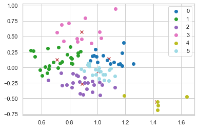

```python
np.random.seed(42)   # supprimer cette ligne une fois la mise au point terminée

les_centres, l_affectation = clust.kmoyennes(6, pd.DataFrame(X_projected_2D), 0.05, 100)

print("Affichage des centres: \n",les_centres)
print("Affichage des affectations: \n",l_affectation)

clust.affiche_resultat(pd.DataFrame(X_projected_2D),les_centres,l_affectation)
```

## Conclusion

Pour l'algorithme des K-moyennes, comme la version de la fonction qui calcule l'inertie n'est pas adaptée pour chaque valeur de K dans l'algorithme de K-moyennes, on va utiliser la classe `KMeans` de la librairie `sklearn.cluster`. Avec l'application de la méthode de coude, on a constaté que $k=4$ est le meilleur nombre de clusters pour effectuer les calculs des K-moyennes.

Après l'application avec plusieurs valeurs de $k$, dont $k\in\{3,4,5,6\}$, on trouve que $k=4$ renvoit le meilleur taux d'accuracy de $0.5$, tandis que pour les autres valeurs de $k$, les taux d'accuracy varient entre $0.2$ à $0.4$.